# Venture Tutorial Part 2

Owain Evans (06.2014)

## Inferring the Mean and Variance of a Gaussian Distribution

### 1. Specifying and plotting the prior

These are the heights of a group of a 18-year-old men. We'd like to make an inference about the population based on this data.

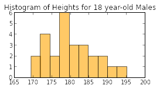

```python
from venture.venturemagics.ip_parallel import MRipl,make_puma_church_prime_ripl,make_puma_venture_script_ripl

data=[179,195.1,183.7,178.7,171.5,181.8,172.5,
        174.6,190.4,173.8,172.6,185.2,178.4,
        177.6,183.5,178.1,177,172.9,188.4,169.4,
        180.2,189,182.4,185.8,180.7,178.7]

fig,ax=plt.subplots(figsize=(4,2))
ax.hist(data, alpha=.6, color='orange')
ax.set_title('Histogram of Heights for 18 year-old Males');
```

We model the population distribution as a Gaussian with unknown mean `mu` and standard deviation `sigma`. We place broad priors on each of the variables. We then define `x` as a stochastic procedure (using `lambda`) that samples a height i.i.d. given `mu` and `sigma`.

```python
v=MRipl(80,local_mode=True, syntax='church_prime')
```

```python
%%venture v 2
[assume mu (normal 0 60) ]
[assume sigma (gamma 2 .2) ]
[assume x (lambda () (normal mu sigma) ) ]
```

```
Ripl 0 of 80:  [8.035116487120552, 11.607440026103758, 'unknown']
Ripl 1 of 80:  [18.383970739828563, 8.336089577294677, 'unknown']
...
```

```python
vs=MRipl(80,local_mode=True, syntax='venture_script')
```

```python
%%venture vs 2
assume mu = normal(0,60)
assume sigma = gamma(2,.2)
assume x  = proc(){ normal(mu,sigma) }
```

```
Ripl 0 of 80:  [8.035116487120552, 11.607440026103758, 'unknown']
Ripl 1 of 80:  [18.383970739828563, 8.336089577294677, 'unknown']
...
```

We can visualize our prior on `mu` and `sigma`, as well as their covariation, via the `scatter` optional argument for `snapshot`.

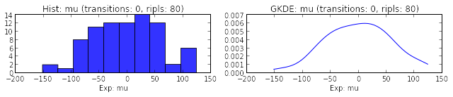

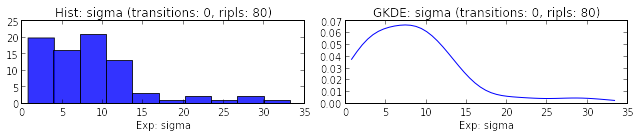

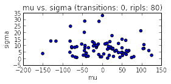

```python
prior = v.snapshot(('mu','sigma'), plot=True, scatter=True)
```

Each pair (`mu`, `sigma`) produces a distinct Gaussian population distribution generated from sampling the stochastic procedure `x`. Using the MRipl method `sample_populations`, we can plot some of these populations (sampled from the model prior).

The form is:

```python
<mripl>.sample_populations(<stochastic_expression>, <number_populations>, <population_size>)
```

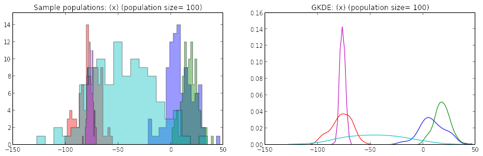

```python
out = v.sample_populations('(x)', 5, 100)
```

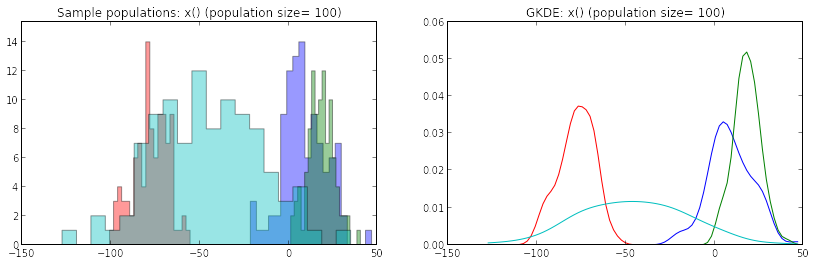

```python
out = vs.sample_populations('x()', 4, 100)
```

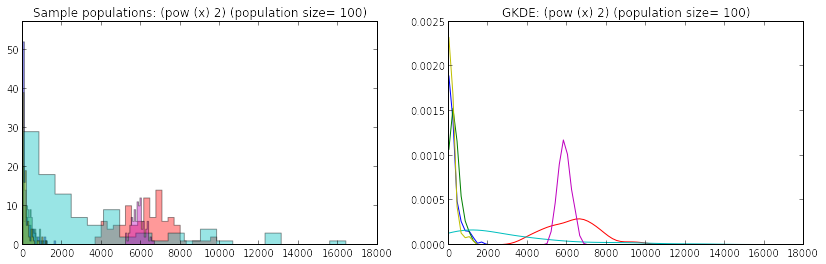

```python
squared_x = v.sample_populations('(pow (x) 2)', 6, 100)
```

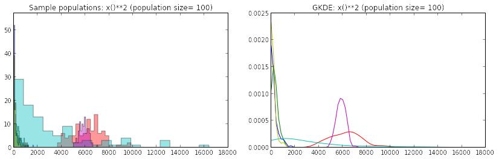

```python
squared_x = vs.sample_populations('x()**2', 6, 100)
```

The `sample_populations` plots above show populations drawn from a subset of the RIPLs in the MRipl. Each population is shown in a different color. To estimate the marginal prior on the heights (i.e. on a sample from `(x)`) we would compute a weighted averaged over all sampled populations from the MRipl. Using the `snapshot` optional argument `repeat = <number_samples>` we sample `<number_samples>` times from each RIPL and collapse all samples into one histogram.

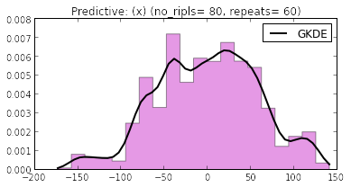

```python
outs = v.snapshot('(x)', plot=True, repeat=60)
```

### 2. Conditioning the model on data

```python
from venture.venturemagics.ip_parallel import MRipl
gaussian_model = '''
[assume mu (normal 0 60) ]
[assume sigma (gamma 2 .2) ]
[assume x (lambda () (normal mu sigma) ) ]
'''
data=[179,195.1,183.7,178.7,171.5,181.8,172.5,
        174.6,190.4,173.8,172.6,185.2,178.4,
        177.6,183.5,178.1,177,172.9,188.4,169.4,
        180.2,189,182.4,185.8,180.7,178.7]
v=MRipl(80,local_mode=True,syntax='church_prime')
out = v.execute_program(gaussian_model)
```

```python
gaussian_model_s='''
assume mu = normal(0,60)
assume sigma = gamma(2,.2)
assume x  = proc(){ normal(mu,sigma) }
'''
vs=MRipl(80,local_mode=True,syntax='venture_script')
out = vs.execute_program(gaussian_model_s)
```

We condition the model using the `observe` directive. As with the 'Tricky Coin' example, we can either condition *incrementally*, interleaving `observe` and `infer` directives, or we can condition on all the data at once. Here we exhibit incremental conditioning.

```
Observed data:
5: observe (x) = 	179
```

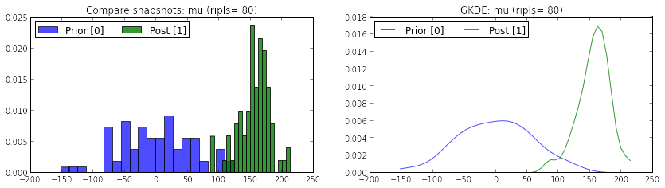

```python
prior_mu = v.snapshot('mu')

v.observe('(x)', data[0] )
print 'Observed data: '
v.print_directives('observe')

v.infer(500)
posterior1_mu = v.snapshot('mu')
fig = v.compare_snapshots( (prior_mu,posterior1_mu) )
```

```python
prior_mu = vs.snapshot('mu')

vs.observe('x()', data[0] )
print 'Observed data: '
vs.print_directives('observe')

vs.infer(500)
posterior1_mu = vs.snapshot('mu')
fig = vs.compare_snapshots( (prior_mu,posterior1_mu) )
```

[output not shown]

[output not shown]

[output cut: 19 more lines]

[output not shown]

```
Observed data:
5: observe (x) = 	179
7: observe (x) = 	195.1
```

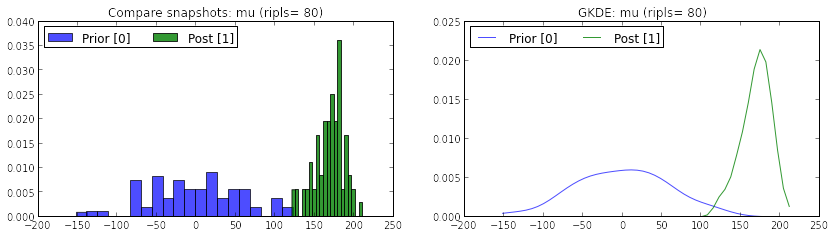

```python
v.observe('(x)',data[1] )

print 'Observed data: '
v.print_directives('observe')

v.infer(500)
posterior2_mu = v.snapshot('mu')

# NOTE: we are comparing the posterior given two data-points to the original prior:
# i.e. the prior before conditioning on any data
fig = v.compare_snapshots( (prior_mu,posterior2_mu) )
```

```
Observed data:
5: observe (x) = 	179
7: observe (x) = 	195.1
9: observe (x) = 	183.7
10: observe (x) = 	178.7
```

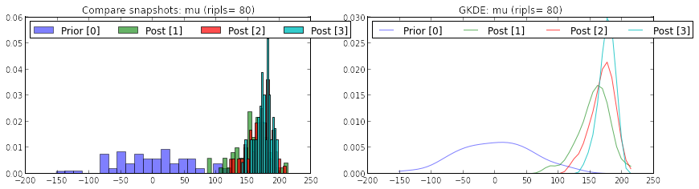

```python
v.observe('(x)', data[2] )
v.observe('(x)', data[3] )

print 'Observed data: '
v.print_directives('observe')

v.infer(500)
posterior3_mu = v.snapshot('mu')
fig = v.compare_snapshots( (prior_mu, posterior1_mu, posterior2_mu, posterior3_mu) )
```

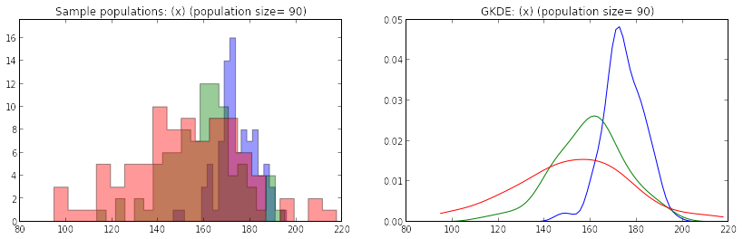

```python
populations = v.sample_populations('(x)', 3, 90)
```

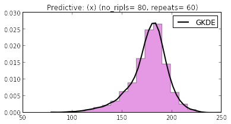

```python
posterior_marginal_x = v.snapshot('(x)', plot=True, repeat=60)
```

```python
from venture.venturemagics.ip_parallel import MRipl
male18=[179,195.1,183.7,178.7,171.5,181.8,172.5,
        174.6,190.4,173.8,172.6,185.2,178.4,
        177.6,183.5,178.1,177,172.9,188.4,169.4,
        180.2,189,182.4,185.8,180.7,178.7]
data=male18
v=MRipl(20,local_mode=True)
```

```python
%%venture v 0
[assume mu (normal 0 60) ]
[assume sigma (gamma 2 .2) ]
[assume x (lambda () (normal mu sigma))]
```

```
...
```